# Assignment 09: Data Scraping

Sara Diamond

# Total points:

## OVERVIEW

This exercise accompanies the lessons in Environmental Data Analytics on data scraping.

## Directions

1. Change “Student Name” on line 3 (above) with your name.
2. Work through the steps, **creating code and output** that fulfill each instruction.
3. Be sure to **answer the questions** in this assignment document.
4. When you have completed the assignment, **Knit** the text and code into a single PDF file.
5. After Knitting, submit the completed exercise (PDF file) to the dropbox in Sakai. Add your last name into the file name (e.g., “Fay_09_Data_Scraping.Rmd”) prior to submission.

## Set up

1. Set up your session:
- Check your working directory
- Load the packages `tidyverse`, `rvest`, and any others you end up using.
- Set your ggplot theme

```r
#1 working directory and laoding packages
getwd()
```

```
## [1] "/Users/saradiamond/Documents/Environmental_Data_Analytics_2022"
```

```r
setwd("/Users/saradiamond/Documents/Environmental_Data_Analytics_2022")
library(tidyverse)
library(rvest)
library(lubridate)

#setting them
mytheme <- theme_classic() +
  theme(axis.text = element_text(color = "black"),
        legend.position = "top")
theme_set(mytheme)
```

2. We will be scraping data from the NC DEQs Local Water Supply Planning website, specifically the Durham’s 2019 Municipal Local Water Supply Plan (LWSP):
- Navigate to https://www.ncwater.org/WUDC/app/LWSP/search.php
- Change the date from 2020 to 2019 in the upper right corner.
- Scroll down and select the LWSP link next to Durham Municipality.
- Note the web address: https://www.ncwater.org/WUDC/app/LWSP/report.php?pwsid=03-32-010&year=2020

Indicate this website as the as the URL to be scraped. (In other words, read the contents into an `rvest` webpage object.)

```r
#2 reading
the_url <- read_html('https://www.ncwater.org/WUDC/app/LWSP/report.php?pwsid=03-32-010&year=2020')
the_url
```

```
## {html_document}
## <html xmlns="http://www.w3.org/1999/xhtml" lang="en" xml:lang="en">
## [1] <head>\n<title>DWR :: Local Water Supply Planning</title>\n<meta http-equ ...
## [2] <body id="plan">\r\n<!--<div id="division-header">\r\n<a name="top" href= ...
```

3. The data we want to collect are listed below:
- From the “1. System Information” section:
- Water system name
- PWSID
- Ownership
- From the “3. Water Supply Sources” section:
- Average Daily Use (MGD) - for each month

In the code chunk below scrape these values, assigning them to three separate variables.

> HINT: The first value should be “Durham”, the second “03-32-010”, the third “Municipality”, and the last should be a vector of 12 numeric values, with the first value being 36.0100.

```r
#3 scraping in the system information section
water.system.name <-  the_url %>%
  html_nodes("div+ table tr:nth-child(1) td:nth-child(2)") %>%
  html_text()

pwsid <- the_url %>%
  html_nodes("td tr:nth-child(1) td:nth-child(5)") %>%
  html_text()

ownership <- the_url %>%
  html_nodes("div+ table tr:nth-child(2) td:nth-child(4)") %>%
  html_text()

max.withdrawals.mgd <- the_url %>%
  html_nodes("th~ td+ td") %>%
  html_text()
```

4. Convert your scraped data into a dataframe. This dataframe should have a column for each of the 4 variables scraped and a row for the month corresponding to the withdrawal data. Also add a Date column that includes your month and year in data format. (Feel free to add a Year column too, if you wish.)

> TIP: Use `rep()` to repeat a value when creating a dataframe.

> NOTE: It’s likely you won’t be able to scrape the monthly widthrawal data in order. You can overcome this by creating a month column in the same order the data are scraped: Jan, May, Sept, Feb, etc…
5. Plot the max daily withdrawals across the months for 2020

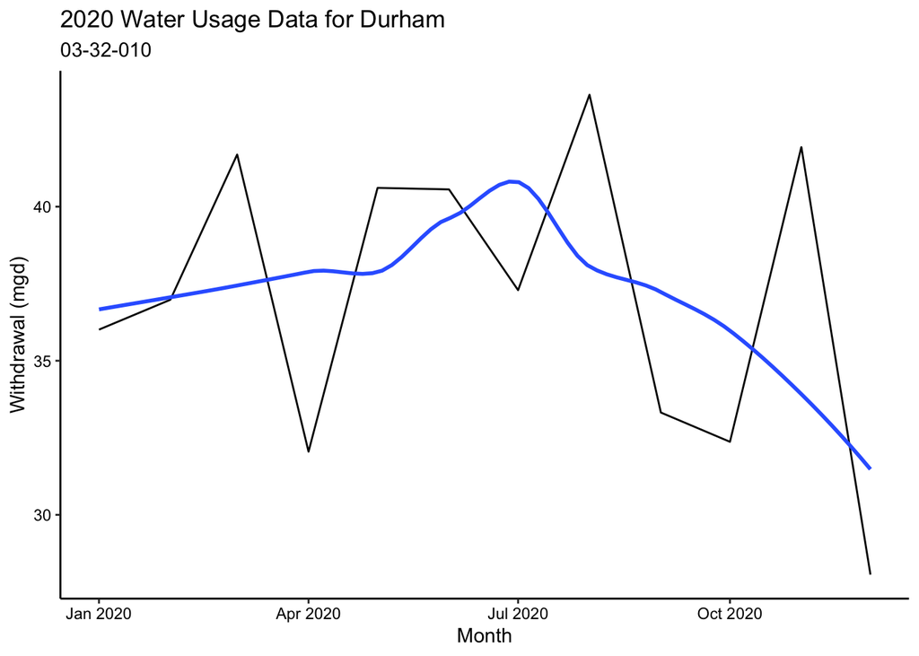

```r
#4 creating a dataframe and naming the columns accordinglh
df_withdrawals <- data.frame("Month" = rep(1:12),
                             "Year" = rep(2020,12),
                             "Max_Withdrawals_mgd" = as.numeric(max.withdrawals.mgd))

df_withdrawals <- df_withdrawals %>%
  mutate(Water_System = !!water.system.name,
         PWSID = !!pwsid,
         Ownership = !!ownership,
         Date = my(paste(Month,"-",Year)))

#5 plotting the data
ggplot(df_withdrawals,aes(x=Date,y=Max_Withdrawals_mgd)) +
  geom_line() +
  geom_smooth(method="loess",se=FALSE) +
  labs(title = paste("2020 Water Usage Data for",water.system.name),
       subtitle = pwsid,
       y="Withdrawal (mgd)",
       x="Month")
```

6. Note that the PWSID and the year appear in the web address for the page we scraped. Construct a function using your code above that can scrape data for any PWSID and year for which the NC DEQ has data. **Be sure to modify the code to reflect the year and site scraped**.

```r
#6.
the_base_url <- "https://www.ncwater.org/WUDC/app/LWSP/report.php?"
pwsid_code <- "03-32-010"
the_year <- 2020
the_scrape_url <- paste0(the_base_url, '/', pwsid_code, '/', the_year)
print(the_scrape_url)
```

```
## [1] "https://www.ncwater.org/WUDC/app/LWSP/report.php?/03-32-010/2020"
```

```r
the_website <- read_html(the_scrape_url)

water.scrape.it <- function(the_year, pwsid_code){
  the_url <- read_html(paste0('https://www.ncwater.org/WUDC/app/LWSP/report.php?pwsid=',pwsid_code,'&year=',the_year))


  #Set the element address variables (determined in the previous step)
  water.system.tag <- 'div+ table tr:nth-child(1) td:nth-child(2)'
  pwsid.tag <- 'td tr:nth-child(1) td:nth-child(5)'
  ownership.tag <- 'div+ table tr:nth-child(2) td:nth-child(4)'
  max.withdrawals.mgd.tag <- 'th~ td+ td'

  #Scrape the data items
  the.water.system <- the_url %>% html_nodes(water.system.tag) %>% html_text()
  the.pwsid <- the_url %>%   html_nodes(pwsid.tag) %>%  html_text()
  the.ownership <- the_url %>% html_nodes(ownership.tag) %>% html_text()
  max.withdrawals <- the_url %>% html_nodes(max.withdrawals.mgd.tag) %>% html_text()

  #Convert to a dataframe
  df_withdrawals <- data.frame("Month" = rep(1:12),
                               "Year" = rep(the_year,12),
                               "Max_Withdrawals.mgd" = as.numeric(max.withdrawals)) %>%
    mutate(Water_System = !!the.water.system,
           PWSID = !!the.pwsid,
           Ownership = !!the.ownership,
           Date = my(paste(Month,"-",Year)))

  #Pause for a moment - scraping etiquette
  #Sys.sleep(1) #uncomment this if you are doing bulk scraping!

  #Return the dataframe
  return(df_withdrawals)
}
```

7. Use the function above to extract and plot max daily withdrawals for Durham (PWSID=‘03-32-010’) for each month in 2015

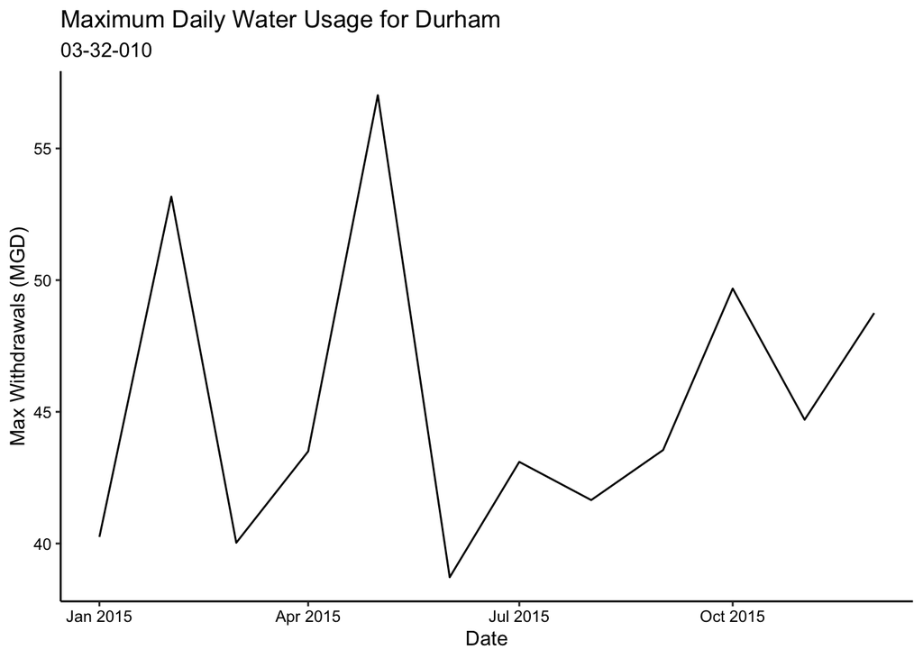

```r
#7 getting the data for Durham for 2015

water.durham.2015 <- water.scrape.it(2015, "03-32-010")

#plotting the data
ggplot(water.durham.2015) +
  geom_line(aes(x = Date, y = Max_Withdrawals.mgd)) +
  labs(x = "Date", y = "Max Withdrawals (MGD)", title = "Maximum Daily Water Usage for Durham", subtitle = pwsid)
```

8. Use the function above to extract data for Asheville (PWSID = 01-11-010) in 2015. Combine this data with the Durham data collected above and create a plot that compares the Asheville to Durham’s water withdrawals.

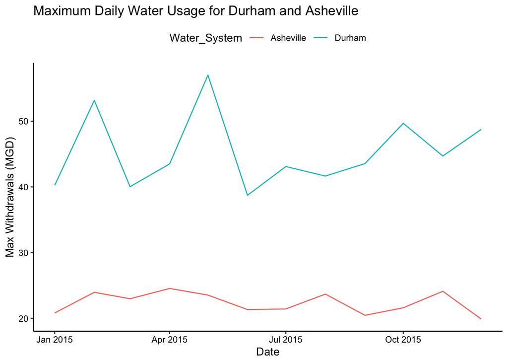

```r
#8 getting data from 2015 from asheville
water.asheville.2015 <- water.scrape.it(2015, "01-11-010")

#combining the data
complete.data <- rbind(water.durham.2015, water.asheville.2015)

#plotting combined data
ggplot(complete.data) +
  geom_line(aes(x = Date, y = Max_Withdrawals.mgd, color = Water_System)) +
  labs(x = "Date", y = "Max Withdrawals (MGD)", title = "Maximum Daily Water Usage for Durham and Asheville")
```

9. Use the code & function you created above to plot Asheville’s max daily withdrawal by months for the years 2010 thru 2019.Add a smoothed line to the plot.

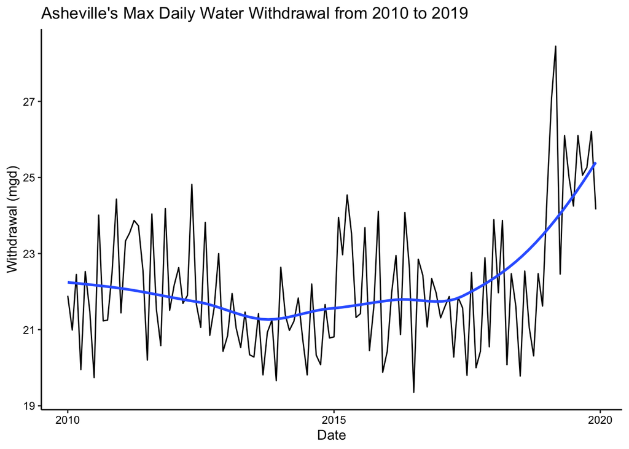

```r
#9
the_year = rep(2010:2019)
pwsid_code = '01-11-010'

asheville.data <- lapply(X = the_year,
                  FUN = water.scrape.it,
                  pwsid_code=pwsid_code)
asheville.dataframe <- bind_rows(asheville.data)

ggplot(asheville.dataframe,aes(x=Date,y=Max_Withdrawals.mgd)) +
  geom_line() +
  geom_smooth(method="loess",se=FALSE) +
  labs(title = paste("Asheville's Max Daily Water Withdrawal from 2010 to 2019"),
       y="Withdrawal (mgd)",
       x="Date")
```

> Question: Just by looking at the plot (i.e. not running statistics), does Asheville have a trend in water usage over time? It seems like there daily max withdrawal has definitely increased over time.